# A7_Isaacson_Sarah

Sarah Isaacson

2024-07-20

# 1 Initial setup & Loading Libraries

```r
# Load the following packages. Install them first if necessary.

knitr::opts_chunk$set(echo = T, warning = F, Message=F)
options(rgl.useNULL = TRUE)
library(e1071)
library(C50)
library(caret)
```

```r
library(rpart)
library(rpart.plot)
library(rJava)
library(RWeka)
library(kernlab)
library(rminer)
library(matrixStats)
library(knitr)
library(tictoc)
library(tidyverse)
library(psych)
library(ggplot2)
library(scales)
library(corrplot)
tic()
```

# 2 Package load, data import, inspection, and partitioning

## 2.1 Package Loading and Census Data

```r
# Importing Data from input file
cloud_wd <- getwd()
setwd(cloud_wd)

cd <- read.csv(file = "census.csv", stringsAsFactors = T)

# Structure
str(cd)
```

```
## 'data.frame':    32561 obs. of  15 variables:
##  $ age           : int  39 50 38 53 28 37 49 52 31 42 ...
##  $ workclass     : Factor w/ 9 levels " ?"," Federal-gov",..: 8 7 5 5 5 5 5 7 5 5 ...
##  $ fnlwgt        : int  77516 83311 215646 234721 338409 284582 160187 209642 45781 159449 ...
##  $ education     : Factor w/ 16 levels " 10th"," 11th",..: 10 10 12 2 10 13 7 12 13 10 ...
##  $ education.num : int  13 13 9 7 13 14 5 9 14 13 ...
##  $ marital.status: Factor w/ 7 levels " Divorced"," Married-AF-spouse",..: 5 3 1 3 3 3 4 3 5 3 ...
##  $ occupation    : Factor w/ 15 levels " ?"," Adm-clerical",..: 2 5 7 7 11 5 9 5 11 5 ...
##  $ relationship  : Factor w/ 6 levels " Husband"," Not-in-family",..: 2 1 2 1 6 6 2 1 2 1 ...
##  $ race          : Factor w/ 5 levels " Amer-Indian-Eskimo",..: 5 5 5 3 3 5 3 5 5 5 ...
##  $ sex           : Factor w/ 2 levels " Female"," Male": 2 2 2 2 1 1 1 2 1 2 ...
##  $ capital.gain  : int  2174 0 0 0 0 0 0 0 14084 5178 ...
##  $ capital.loss  : int  0 0 0 0 0 0 0 0 0 0 ...
##  $ hours.per.week: int  40 13 40 40 40 40 16 45 50 40 ...
##  $ native.country: Factor w/ 42 levels " ?"," Cambodia",..: 40 40 40 40 6 40 24 40 40 40 ...
##  $ y             : Factor w/ 2 levels " <=50K"," >50K": 1 1 1 1 1 1 1 2 2 2 ...
```

```r
summary(cd)
```

```
##       age                    workclass         fnlwgt
##  Min.   :17.00    Private         :22696   Min.   :  12285
##  1st Qu.:28.00    Self-emp-not-inc: 2541   1st Qu.: 117827
##  Median :37.00    Local-gov       : 2093   Median : 178356
##  Mean   :38.58    ?               : 1836   Mean   : 189778
##  3rd Qu.:48.00    State-gov       : 1298   3rd Qu.: 237051
##  Max.   :90.00    Self-emp-inc    : 1116   Max.   :1484705
##                  (Other)          :  981
##          education     education.num                  marital.status
##   HS-grad     :10501   Min.   : 1.00    Divorced             : 4443
##   Some-college: 7291   1st Qu.: 9.00    Married-AF-spouse    :   23
##   Bachelors   : 5355   Median :10.00    Married-civ-spouse   :14976
##   Masters     : 1723   Mean   :10.08    Married-spouse-absent:  418
##   Assoc-voc   : 1382   3rd Qu.:12.00    Never-married        :10683
##   11th        : 1175   Max.   :16.00    Separated            : 1025
##  (Other)      : 5134                    Widowed              :  993
##             occupation            relationship                    race
##   Prof-specialty :4140    Husband       :13193    Amer-Indian-Eskimo:  311
##   Craft-repair   :4099    Not-in-family : 8305    Asian-Pac-Islander: 1039
##   Exec-managerial:4066    Other-relative:  981    Black             : 3124
##   Adm-clerical   :3770    Own-child     : 5068    Other             :  271
##   Sales          :3650    Unmarried     : 3446    White             :27816
##   Other-service  :3295    Wife          : 1568
##  (Other)         :9541
##       sex         capital.gain    capital.loss    hours.per.week
##   Female:10771   Min.   :    0   Min.   :   0.0   Min.   : 1.00
##   Male  :21790   1st Qu.:    0   1st Qu.:   0.0   1st Qu.:40.00
##                  Median :    0   Median :   0.0   Median :40.00
##                  Mean   : 1078   Mean   :  87.3   Mean   :40.44
##                  3rd Qu.:    0   3rd Qu.:   0.0   3rd Qu.:45.00
##                  Max.   :99999   Max.   :4356.0   Max.   :99.00
##
##         native.country       y
##   United-States:29170    <=50K:24720
##   Mexico       :  643    >50K : 7841
##   ?            :  583
##   Philippines  :  198
##   Germany      :  137
##   Canada       :  121
##  (Other)       : 1709
```

## 2.2 Correlation Analysis

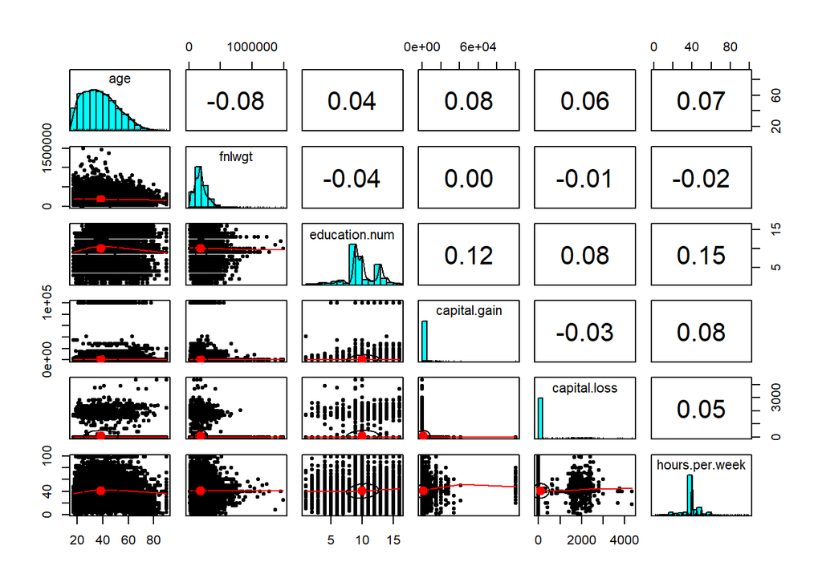

```r
# Using pairpanels on numeric predictors
cd %>% select(where(is.numeric)) %>% pairs.panels()
```

## 2.3 Exploratory data Analysis

After Exploration, We find that the variable education.num should be a factor to better understand our data.

```r
cd <- cd %>%
  mutate(education.num = factor(education.num))
```

```r
# Checking for NA
(cd %>% summarize(across(everything(), ~ sum(is.na(.)))))
```

```
##   age workclass fnlwgt education education.num marital.status occupation
## 1   0         0      0         0             0              0          0
##   relationship race sex capital.gain capital.loss hours.per.week native.country
## 1            0    0   0            0            0              0              0
##   y
## 1 0
```

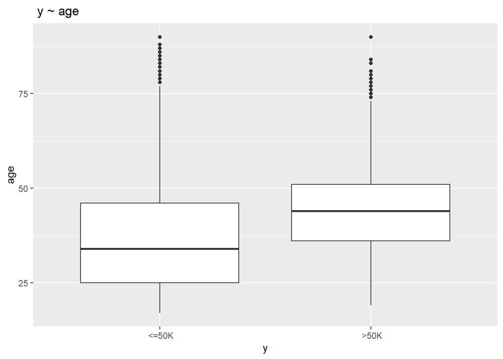

```r
# Box plots for age
cd %>%
  ggplot()+
  geom_boxplot(aes(x =y,y=age))+
  ggtitle(" y ~ age")
```

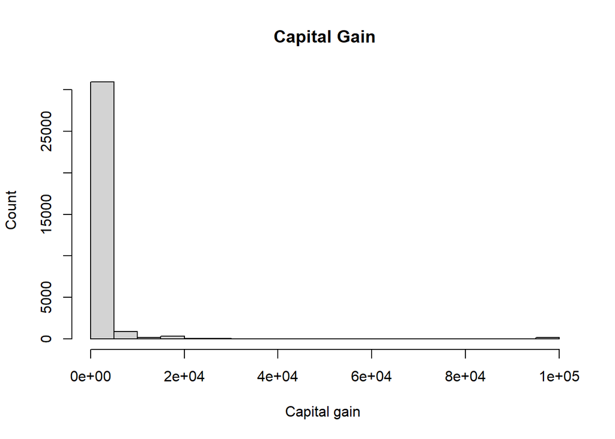

```r
# Using histogram to see skewed nature of Capital Gain
hist((cd$capital.gain), xlab = 'Capital gain ', ylab = 'Count', main = 'Capital Gain')
```

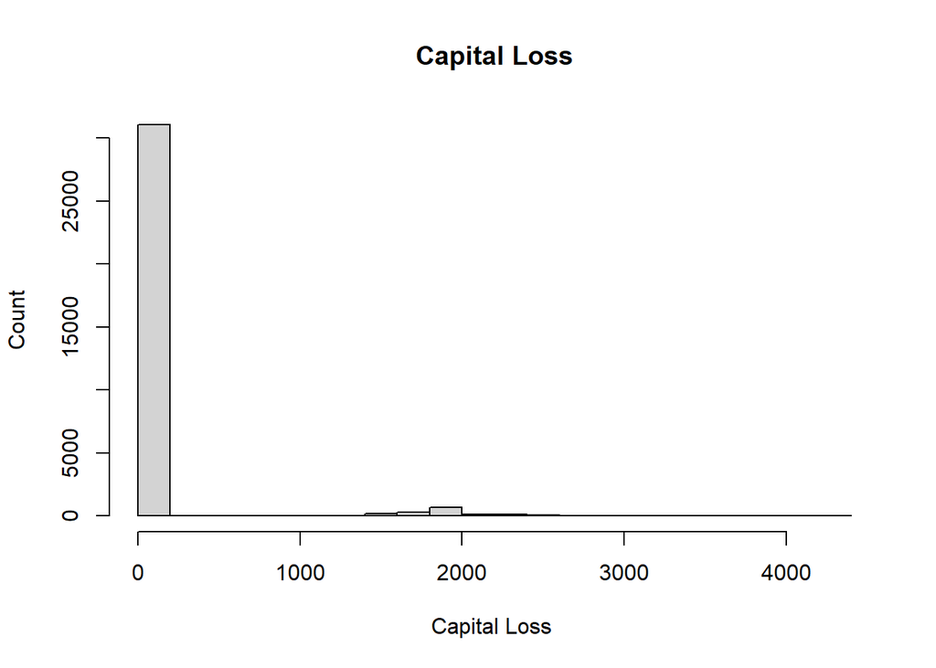

```r
# Using histogram to see skewed nature of Capital Loss
hist((cd$capital.loss), xlab = 'Capital Loss ', ylab = 'Count', main = 'Capital Loss')
```

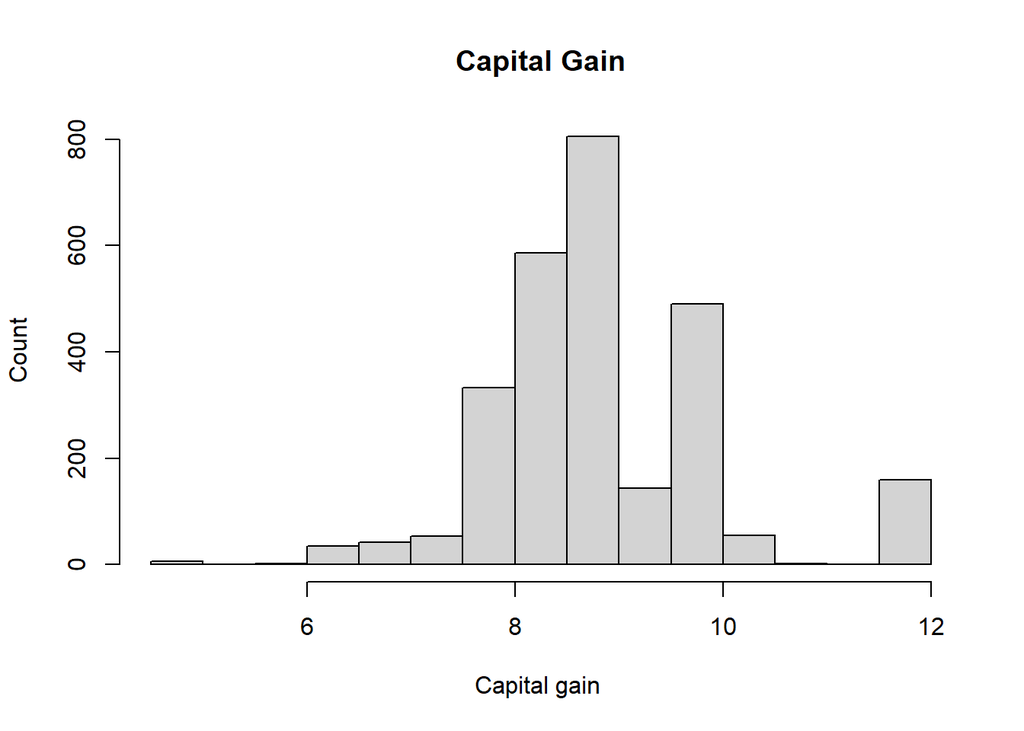

```r
# Logging Capital gain and Capital Loss
cd_log <- cd %>%
  mutate(capital.gain = log(capital.gain),
         capital.loss = log(capital.loss))
hist((cd_log$capital.gain), xlab = 'Capital gain ', ylab = 'Count', main = 'Capital Gain')
```

```r
# Marital status against y proportion
prop.table(table(cd$marital.status, cd$y))*100
```

```
##
##                                <=50K        >50K
##    Divorced              12.22321182  1.42194650
##    Married-AF-spouse      0.03992506  0.03071159
##    Married-civ-spouse    25.44147907 20.55219434
##    Married-spouse-absent  1.17932496  0.10441940
##    Never-married         31.30124996  1.50793895
##    Separated              2.94524124  0.20269648
##    Widowed                2.78861214  0.26104849
```

```r
# Relationship against y
prop.table(table(cd$relationship, cd$y))*100
```

```
##
##                        <=50K       >50K
##    Husband        22.3426799 18.1751175
##    Not-in-family  22.8770615  2.6289119
##    Other-relative  2.8991739  0.1136329
##    Own-child      15.3588649  0.2057676
##    Unmarried       9.9137004  0.6695126
##    Wife            2.5275636  2.2880133
```

```r
# workclass against y
prop.table(table(cd$workclass, cd$y))*100
```

```
##
##                           <=50K        >50K
##    ?                 5.05205614  0.58659132
##    Federal-gov       1.80891250  1.13939990
##    Local-gov         4.53303031  1.89490495
##    Never-worked      0.02149811  0.00000000
##    Private          54.46085808 15.24216087
##    Self-emp-inc      1.51715242  1.91026074
##    Self-emp-not-inc  5.58029545  2.22351893
##    State-gov         2.90224502  1.08411904
##    Without-pay       0.04299622  0.00000000
```

```r
# education against y
prop.table(table(cd$education, cd$y))*100
```

```
##
##                       <=50K        >50K
##    10th          2.67497927  0.19041184
##    11th          3.42434200  0.18426952
##    12th          1.22846350  0.10134824
##    1st-4th       0.49752772  0.01842695
##    5th-6th       0.97355732  0.04913854
##    7th-8th       1.86112220  0.12284635
##    9th           1.49565431  0.08292129
##    Assoc-acdm    2.46306932  0.81385707
##    Assoc-voc     3.13565308  1.10868831
##    Bachelors     9.62501152  6.82104358
##    Doctorate     0.32861399  0.93977458
##    HS-grad      27.10604711  5.14419090
##    Masters       2.34636528  2.94524124
##    Preschool     0.15662910  0.00000000
##    Prof-school   0.46988729  1.29910015
##    Some-college 18.13212125  4.25969718
```

```r
# sex against y
prop.table(table(cd$sex, cd$y))*100
```

```
##
##               <=50K      >50K
##    Female 29.458555  3.620896
##    Male   46.460490 20.460060
```

```r
# native country against y
prop.table(table(cd$native.country, cd$y))*100
```

```
##
##                                      <=50K         >50K
##    ?                           1.342096373  0.448389177
##    Cambodia                    0.036853905  0.021498111
##    Canada                      0.251835017  0.119775191
##    China                       0.168913731  0.061423175
##    Columbia                    0.175056049  0.006142317
##    Cuba                        0.214981112  0.076778969
##    Dominican-Republic          0.208838795  0.006142317
##    Ecuador                     0.073707810  0.012284635
##    El-Salvador                 0.297902399  0.027640429
##    England                     0.184269525  0.092134762
##    France                      0.052209699  0.036853905
##    Germany                     0.285617764  0.135130985
##    Greece                      0.064494334  0.024569270
##    Guatemala                   0.187340684  0.009213476
##    Haiti                       0.122846350  0.012284635
##    Holand-Netherlands          0.003071159  0.000000000
##    Honduras                    0.036853905  0.003071159
##    Hong                        0.042996222  0.018426952
##    Hungary                     0.030711587  0.009213476
##    India                       0.184269525  0.122846350
##    Iran                        0.076778969  0.055280857
##    Ireland                     0.058352016  0.015355794
##    Italy                       0.147415620  0.076778969
##    Jamaica                     0.218052271  0.030711587
##    Japan                       0.116704032  0.073707810
##    Laos                        0.049138540  0.006142317
##    Mexico                      1.873406836  0.101348239
##    Nicaragua                   0.098277080  0.006142317
##    Outlying-US(Guam-USVI-etc)  0.042996222  0.000000000
##    Peru                        0.089063604  0.006142317
##    Philippines                 0.420748749  0.187340684
##    Poland                      0.147415620  0.036853905
##    Portugal                    0.101348239  0.012284635
##    Puerto-Rico                 0.313258192  0.036853905
##    Scotland                    0.027640429  0.009213476
##    South                       0.196554160  0.049138540
##    Taiwan                      0.095205921  0.061423175
##    Thailand                    0.046067381  0.009213476
##    Trinadad&Tobago             0.052209699  0.006142317
##    United-States              67.562421302 22.023279383
##    Vietnam                     0.190411842  0.015355794
##    Yugoslavia                  0.030711587  0.018426952
```

[output not shown]

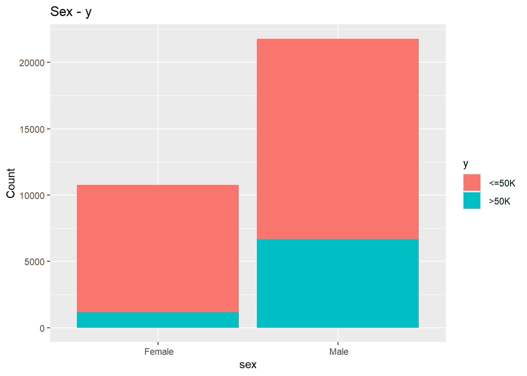

```r
# Distribution of income on basis of sex

cd %>%
  group_by(y, sex) %>%
  summarise(Count= n()) %>%
  ggplot() +
  geom_col(aes(x=sex, y=Count, fill = y)) +
  ggtitle("Sex - y")
```

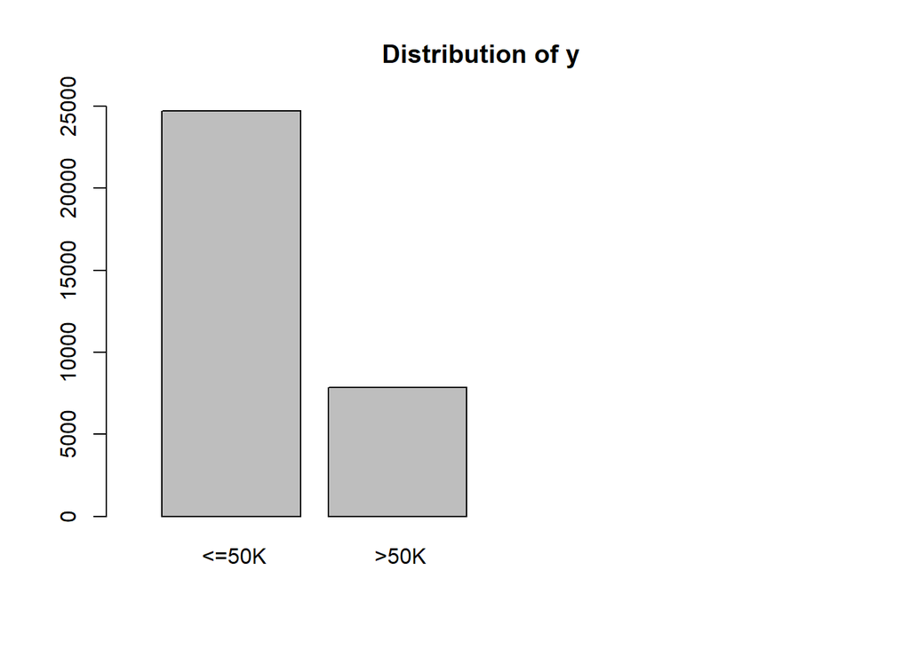

```r
#Simple distribution of income classification
plot(cd$y,xlim = c(0, 5),  ylim = c(0,25000), main = "Distribution of y")
```

### 2.3.1 Majority Classifier

```r
# percentage distribution of income - y in data set

prop.table(table(cd$y))*100
```

```
##
##    <=50K     >50K
## 75.91904 24.08096
```

The accuracy of the majority classifier will be 75.9% where our majority is “<=50K”

## 2.4 Comment

Target Variable - Categorical All Known Modelling Algorithms

Decision tree C5.0 Naive Bayes Ibk KNN RPart MLP KSVM Clustering K Means Linear Regression ( Not for classification) M5P in RWeka ( Not for classification)

Suitable for categorical: Naive Bayes C5.0 Rpart KNN KSVM MLP (complex)

# 3 Cross Validation

```r
# 1.Randomly sample 70% of the rows
set.seed(100)

# Data Partitioning set
inTrain <- createDataPartition(y=cd$y, p = 0.70, list=FALSE)
train_target <- cd[inTrain,15]
test_target <- cd[-inTrain,15]
train_input <- cd[inTrain,-15]
test_input <- cd[-inTrain,-15]
```

## 3.1 Evaluation and Proportion of target variable

```r
# creating a vector with evaluation metrics.

tree_metrics <- c("ACC","F1","PRECISION","TPR")

cd %>% pull(y) %>% table() %>% prop.table() %>% round(2)
```

```
## .
##  <=50K   >50K
##   0.76   0.24
```

```r
prop.table(table(train_target))*100
```

```
## train_target
##    <=50K     >50K
## 75.91805 24.08195
```

```r
prop.table(table(test_target))*100
```

```
## test_target
##    <=50K     >50K
## 75.92138 24.07862
```

## 3.2 Cross Validation Function

```r
cv_function <- function(df, target, nFolds, seedVal, prediction_method, metrics_list)
{
  # create folds
  set.seed(seedVal)
  folds = createFolds(df[,target],nFolds)
  # perform cross validation
  cv_results <- lapply(folds, function(x)
  {
    test_target <- df[x,target]
    test_input  <- df[x,-target]

    train_target <- df[-x,target]
    train_input <- df[-x,-target]

    prediction_model <- ksvm(train_target~.,train_input)
    pred<- predict(prediction_model,test_input)
    return(mmetric(test_target,pred,metrics_list))
  })
  # generate means and sds and show cv results, means and sds using kable
  cv_results_m <- as.matrix(as.data.frame(cv_results))
  cv_mean<- as.matrix(rowMeans(cv_results_m))
  cv_sd <- as.matrix(rowSds(cv_results_m))
  colnames(cv_mean) <- "Mean"
  colnames(cv_sd) <- "Sd"
  cv_all <- cbind(cv_results_m, cv_mean, cv_sd)
  kable(t(cv_all),digits=2)
}
```

# 4 Modelling Data

## 4.1 C5.0 Decision Tree

```r
# Using multiple Cost Factors

# CF = 0.85  acc = 86.00
# CF = 0.45  acc = 86.50
# Cf = 0.30  acc = 86.7
# CF = 0.20  acc = 86.86
# CF = 0.08  acc = 86.5

dtree <- C5.0(train_input, train_target, control = C5.0Control(CF=0.08, earlyStopping = FALSE, noGlobalPruning = FALSE))
tree_test <- predict(dtree, test_input)

#tree size
dtree$size
```

```
## [1] 36
```

```r
summary(dtree)
```

```
##
## Call:
## C5.0.default(x = train_input, y = train_target, control = C5.0Control(CF
##  = 0.08, earlyStopping = FALSE, noGlobalPruning = FALSE))
##
##
## C5.0 [Release 2.07 GPL Edition]      Wed Jul 24 21:04:51 2024
## -------------------------------
##
## Class specified by attribute `outcome'
##
## Read 22793 cases (15 attributes) from undefined.data
##
## Decision tree:
##
## capital.gain > 5060:
## :...capital.gain > 6849: >50K (1011/11)
## :   capital.gain <= 6849:
## :   :...marital.status in {Divorced,Married-spouse-absent,Never-married,
## :       :                  Separated,Widowed}: <=50K (35/1)
## :       marital.status in {Married-AF-spouse,
## :                          Married-civ-spouse}: >50K (81/1)
## capital.gain <= 5060:
## :...relationship in {Not-in-family,Other-relative,Own-child,Unmarried}:
##     :...capital.loss > 2206: >50K (69/31)
##     :   capital.loss <= 2206:
##     :   :...capital.gain <= 4650: <=50K (12157/544)
##     :       capital.gain > 4650: >50K (32/14)
##     relationship in {Husband,Wife}:
##     :...capital.loss > 1762:
##         :...capital.loss <= 1980: >50K (398/9)
##         :   capital.loss > 1980:
##         :   :...capital.loss <= 2149: <=50K (38)
##         :       capital.loss > 2149:
##         :       :...capital.loss > 2415: <=50K (9)
##         :           capital.loss <= 2415:
##         :           :...capital.loss > 2377: >50K (37)
##         :               capital.loss <= 2377:
##         :               :...age <= 64: <=50K (15/1)
##         :                   age > 64: >50K (20/2)
```

[output cut: 78 more lines]

```
##  Attribute usage:
##
##  100.00% capital.gain
##   95.06% relationship
##   95.06% capital.loss
##   39.01% education
##   36.09% age
##   29.75% hours.per.week
##   25.67% occupation
##   17.64% race
##    6.93% workclass
##    0.51% marital.status
##
##
## Time: 0.3 secs
```

```r
mmetric(test_target, tree_test, metric=tree_metrics)
```

```
##        ACC        F11        F12 PRECISION1 PRECISION2       TPR1       TPR2
##   86.57862   91.43081   69.05830   88.72257   77.61273   94.30960   62.20238
```

```r
C5imp(dtree)
```

```
##                Overall
## capital.gain    100.00
## relationship     95.06
## capital.loss     95.06
## education        39.01
## age              36.09
## hours.per.week   29.75
## occupation       25.67
## race             17.64
## workclass         6.93
## marital.status    0.51
## fnlwgt            0.00
## education.num     0.00
## sex               0.00
## native.country    0.00
```

## 4.2 Naive Bayes Model

```r
cd_nb <- naiveBayes(train_target ~ ., data = train_input)
nb_pred <- predict(cd_nb, test_input)
mmetric(test_target, nb_pred, metric=tree_metrics)
```

```
##        ACC        F11        F12 PRECISION1 PRECISION2       TPR1       TPR2
##   82.46314   88.94339   57.63047   85.30395   68.89415   92.90723   49.53231
```

## 4.3 Recursive Partitioning - rpart ( For Classification)

```r
# Rpart model
rpart_cd <- rpart(train_target~., data = train_input)
rpart_pred <- predict(rpart_cd, test_input)
mmetric(test_target, rpart_pred, tree_metrics)
```

```
##        ACC        F11        F12 PRECISION1 PRECISION2       TPR1       TPR2
##   83.88616   89.91155   59.98983   85.68287   74.58913   94.57929   50.17007
```

## 4.4 KNN Algorithm using iBK

```r
#K Nearest Neighbours using Ibk

ibk <- IBk(train_target ~ .,data = train_input, control = Weka_control(K=45,X=TRUE, I=TRUE))
ibk_pred_test <- predict(ibk, test_input)
mmetric(test_target, ibk_pred_test, tree_metrics)
```

```
##        ACC        F11        F12 PRECISION1 PRECISION2       TPR1       TPR2
##   83.47666   89.39274   62.63889   87.19231   68.75000   91.70712   57.52551
```

## 4.5 Support Vector Machine or KSVM

```r
# Ksvm model or KVSM model

ksvm <- ksvm(train_target ~ .,data = train_input, kernel = "laplacedot", C=4)
ksvm_pred <- predict(ksvm, test_input)
mmetric(test_target, ksvm_pred, tree_metrics)
```

```
##        ACC        F11        F12 PRECISION1 PRECISION2       TPR1       TPR2
##   85.45250   90.68136   66.85328   88.26759   74.05685   93.23085   60.92687
```

# 5 Reflections

For the prediction, we evaluated 5 different models.

- c5.0 Decision Tree : Acc - 86.5
- Naive Bayes Model : Acc - 82.5
- RPart tree : ACc - 83.8
- KNN - K Nearest Neighbors Algorithm : Acc - 83.5
- SVM - Support Vector Machine : Acc - 85.5

We evaluated five prediction models: C5.0 Decision Tree, Naive Bayes, RPart tree, KNN, and SVM. The C5.0 model achieved the highest accuracy (86.5%) and was selected for its interpretability, allowing us to understand decision splits and predictor importance.

Our model significantly outperforms a random classifier (50%) or a majority class baseline (75.9%), demonstrating its predictive power. It excels at identifying individuals with low income (<=50k).

Incorrectly classifying a low-income person as high-income could lead to missed sales or potential financial hardship for the individual due to loan burdens.